# Chapter 5: Reading and Writing Files

**Goals**

- Learn about coffee extraction and absorbance
- Learn how to import numerical data from different file types (`.xlsx`, `.txt`, `.npy`)
- Learn how to structure and save numerical data
- Understand the basics of a linear model

## 5.1 Setting the Stage

### 5.1.1 Coffee as Application Example for the Upcoming Weeks

In the following weeks, we will look into different aspects of data science with a strong emphasis on the actual steps you have to take in Python. I'm not going to lie: Data science can be both frustrating and boring at times. But when you have a certain **project** or **goal** in mind, i.e. if you are motivated by an application, things generally don't look so bad. You may even discover that you like it!

That being said, the following lectures will focus on **coffee** as an application example. In case you never heard that word, wikipedia provides the following definition:

*Coffee is a beverage prepared from roasted coffee beans. Darkly colored, bitter, and slightly acidic, coffee has a stimulating effect on humans, primarily due to its caffeine content. It has the highest sales in the world market for hot drinks.*

The first step in making coffee is **grinding** the beans to a powder of certain size (distribution). During **extraction**, you add hot water of a certain temperature to the particles and let them do their thing for a certain amount of time. Soluble molecules are passed from the particles into the liquid, making it delicious, acidic, bitter and (probably) help you stay awake while reading this. Note, that we will not go deeper into the actual physical processes than this.

Before we look into the extraction process, we first have to have a measure for the *"degree of extraction"*, i.e. how far / good our extraction has gone. In this lecture we focus on **caffeine concentration**, as it is pretty relatable. In general: Higher or longer extraction yields higher caffeine concentration.

### 5.1.2 Measuring Absorbance and How it's Related to Caffeine Concentrations

Today, we want to set up an analytical routine to measure caffeine concentration. When light is passed through a sample, it partially gets absorbed, i.e. less light comes out than came in. In the case of coffee, these **absorption** values $A$ increase with the concentration of dissolved caffeine molecules $c$. See the figure below to get an understanding of how different caffeine concentrations yield different absorbance values (turbidities), i.e. make the coffee more *"thin"* or *"thick"*. You probably have a vivid understanding of this from everyday life. However, as we are scientist, just looking at the samples isn't sufficiently accurate. Luckily, we have access to a turbidity sensor called ***"TuRbMaSteR 8000"*** that measures the absorbance. However, right now we do not know the connection between absorption and caffeine concentration. Therefore we first have to perform a so-called **calibration** that yields a relationship $c=f(A)$

Firstly, we need **data**. We brew different samples with varying caffeine concentrations $c_{i}$. We give those samples to a fancy lab that determines these values, i.e. the concentration $c_{i}$ of each sample is known. Data like that is often called "*labeled*" data. The ***"TuRbMaSteR 8000"*** gives us the option to save a series of measurements together with concentration labels as text file (.txt). Additionally we received an Excel-Worksheet (.xlsx) from the lab. Our python code can handle both file extensions with the right packages. Here, we will demonstrate how to use the modules of the `pandas` package.

[figure not shown]

**Figure 5.1:** The trusted ***"TuRbMaSteR 8000"***

## 5.2 Data Import

### 5.2.1 Extract Important Information from File Names

When working experimentally and generating large amounts of data, it is crucial that you develop a consistent and understandable **naming convention** and **system** for your files and folders. This allows you to store information into the **file name**, that is accessible before actually looking *into* the file itself. Two examples for **file name information** include:

- A measurement device stores a *timestamp* in the name of the output file (e.g. `231101_*filename*`). This timestamp tells you *when* the data was measured and makes it retraceable within your lab journal.
- You can store secondary information in the file name, e.g. a string attachment `*filename*_60C` which means that your sample was measured at 60°C.

In our example, the ***"TuRbMaSteR 8000"*** measures the absorbance of our samples at a specific *wavelength*. Because we are smart and organized, we save this information in the filename of each sample we measure. An example filename looks like this:

```
230626_caffeine-calib_lam_276.*file extension*
```

A close inspection reveals that the wavelength of $\lambda = 276$ nm is found after the last `_` character, right before the file extension. Let's see if we can extract this numeric value from the string.

Our strategy is as follows:

1. Display all file names in the working directory (path: `'./data/calibration_caffeine_turbmaster/'`) with the `os` package
2. Choose a filename and save its name to a variable as a `str` type
3. Split the `string` at the `_` characters
4. Split the new `string` at the `.` character to get rid of the file extension
5. Save the numerical data of wavelength as a new variable

```python
# Import of needed packages
import os
import numpy as np

# List all filenames in the working directory
list_of_filenames = os.listdir('./data/calibration_caffeine_turbmaster/')
# Choose one filename in the list (here index 0)
filename = list_of_filenames[0]
# Separate string with module split() applied to our string object
filename_separated = filename.split("_")
# Separate the LAST entry of "filename_separated" with module split() to get rid of file extension
extension_separated = filename_separated[-1].split(".")

# Save the FIRST entry of the list "extension_separated" to our variable
turbmaster_800_wavelength = float(extension_separated[0])
## Here we wrapped the last entry in the float() function to ensure the right datatype of our numerical data

print('The original filename was', filename)
print('The filename separated at _ characters yields', filename_separated)
print('The last entry separated at . character yields', extension_separated)
print('TuRbMaSteR 8000 measured the absorbance at wavelength', turbmaster_800_wavelength)
```

```
The original filename was 230626_caffeine-calib_lam_276.txt
The filename separated at _ characters yields ['230626', 'caffeine-calib', 'lam', '276.txt']
The last entry separated at . character yields ['276', 'txt']
TuRbMaSteR 8000 measured the absorbance at wavelength 276.0
```

### 5.2.2 Read Data from Text Files (`.txt`)

Let's have a look inside our textfile (`.txt`) in the working directory sub-path `./data/calibration_caffeine_turbmaster/`:

```
Turbidity Sensor: TuRbMaStEr 8000
Day: 21.06.2023
Time: 15:08:24
Evaluated Wavelength: 276 nm
c [mol/L]; A [1/cm]

5e-05;0,55011
4e-05;0,45458
3e-05;0,33747
2e-05;0,21773
1e-05;0,11484
9e-06;0,09853
8e-06;0,08801
7e-06;0,07882
```

A common challenge is the import of **numerical data** that is stripped of all excess information found in the file **header**. This has to be handled by our code through package options and data transformations we apply in our **data processing pipeline**. There are various packages you can use, but note that performing data import will always depend on the file structure and the information you're after, so you probably have to adjust this to your case.

> Tip: If you describe the file structure and your desired information to ChatGPT, it is (generally) able to help you with an import script!

In this lecture we will use the `pandas` package for data import. It is a large and well-known library for handling and *"cleaning up"* large data sets. Due to time reasons, we cannot go into detail during the lectures. However, besides data import we will not use it (although you technically could!). You can find more information [on the web](https://pandas.pydata.org/docs/user_guide/10min.html). The `pandas` package introduces two variable types (similar to `ndarrays` introduced by `numpy`):

1. `pandas.Series`: A one-dimensional labeled array holding data of any type
2. `pandas.DataFrame`: A two-dimensional data structure that holds data like a two-dimension array or a table with rows and columns.

You access a certain row or column of a `DataFrame` by using the `.iloc[ ]` method (see the example below). This returns a `Series` variable. To extract actual numeric values from a `Series` apply the `.values` keyword.

Our strategy is as follows:

1. Save the path to our text file to a variable as `str` type
2. Read in the numerical data with the pandas package as `DataFrame`
3. Extract concentration and absorbance columns as `Series`
4. Save their values (as `float`) to numpy arrays

> ***Note:*** Python will be confused when working with comma-separated decimals (e.g. `2,5`; a Germany-specific problem). So either make a good habit of saving your decimals directly with a dot as delimiter (e.g. `2.5`) or you have to manually replace them during data processing (as is done in the example below by passing the `decimal` argument).

```python
# Import pandas package
import pandas as pd

# Construct the path variable
path_to_txt = './data/calibration_caffeine_turbmaster/230626_caffeine-calib_lam_276.txt'

# Use pandas to read in data and save to DataFrame
## Option 1: delimiter=';' sets our delimiter (separating the columns)
## Option 2: skiprows=6    ensures that the first 6 rows of header are ignored
## Option 3: header=None   needs to be set otherwise the first row is used as "column names"
## Option 4: decimal=','   sets the character to be recognized as decimal points

# dataframe = pd.read_csv(path_to_txt, delimiter=';', skiprows=4, decimal=',') # <-- Try me as well :)
dataframe = pd.read_csv(path_to_txt, delimiter=';', skiprows=6, header=None, decimal=',')

print('The imported dataframe has type', type(dataframe), 'and the content is:')
print(dataframe)
```

```
The imported dataframe has type <class 'pandas.core.frame.DataFrame'> and the content is:
          0        1
0  0.000050  0.55011
1  0.000040  0.45458
2  0.000030  0.33747
3  0.000020  0.21773
4  0.000010  0.11484
5  0.000009  0.09853
6  0.000008  0.08801
7  0.000007  0.07882
```

```python
# Extract concentration and absorbance data from dataframe with...
## 1) method .iloc[..] (indexing) --> returns pd.Series
## 2) method .astype(..) to ensure the correct data-type of *float*
## 3) attribute .values to access the data inside the Series
c_series = dataframe.iloc[:,0]
A_series = dataframe.iloc[:,1]
print('The variable c_series has type', type(c_series), 'and the following content:')
print(c_series)

c = c_series.astype(float).values
A = A_series.astype(float).values
print('Imported concentration array is', c, 'and has type', type(c))
print('Imported absorbance array is', A, 'and has type', type(A))
```

```
The variable c_series has type <class 'pandas.core.series.Series'> and the following content:
0    0.000050
1    0.000040
2    0.000030
3    0.000020
4    0.000010
5    0.000009
6    0.000008
7    0.000007
Name: 0, dtype: float64
Imported concentration array is [5.e-05 4.e-05 3.e-05 2.e-05 1.e-05 9.e-06 8.e-06 7.e-06] and has type <class 'numpy.ndarray'>
Imported absorbance array is [0.55011 0.45458 0.33747 0.21773 0.11484 0.09853 0.08801 0.07882] and has type <class 'numpy.ndarray'>
```

### 5.2.3 Read Data from Excel Files (`.xlsx`)

Due to the widespread use of MS Excel, you will often be confronted with the task of reading data from `.xlsx` files. Again, we will use the `pandas` package to import the content of our Excel Spreadsheet, stored in the same working directory sub-path. Because our lab boys and girls are very serious, this excel file is highly customized with headlines, colors and a graph:

[figure not shown]

Again, our challenge is the extraction of the important **numerical data** at a specific column location in the Excel Sheet. We do also have to care about the **header**. As you will see, the strategy and code will not change massively to the previous example!

```python
# Construct the path variable
path_to_xlsx = './data/calibration_caffeine_turbmaster/230626_caffeine-calib_lam_276.xlsx'

# Use pandas to read in data and save to DataFrame
## Option 1: sheet_name=0   defines the sheet in the workbook to look at
dataframe_excel = pd.read_excel(path_to_xlsx, sheet_name=0, skiprows=2, header=None)
print('The imported dataframe has type', type(dataframe_excel), 'and the content is:')
print(dataframe_excel)

# Extract concentration and absorbance data (same syntax)
c = dataframe_excel.iloc[:,2].astype(float).values
A = dataframe_excel.iloc[:,3].astype(float).values

print('Imported concentration array (source: .xlsx file): ', c)
print('Imported absorbance array (source: .xlsx file): ', A)
```

```
The imported dataframe has type <class 'pandas.core.frame.DataFrame'> and the content is:
   0          1         2        3
0  1 2023-06-21  0.000050  0.55011
1  2 2023-06-21  0.000040  0.45458
2  3 2023-06-21  0.000030  0.33747
3  4 2023-06-21  0.000020  0.21773
4  5 2023-06-22  0.000010  0.11484
5  6 2023-06-22  0.000009  0.09853
6  7 2023-06-22  0.000008  0.08801
7  8 2023-06-23  0.000007  0.07882
Imported concentration array (source: .xlsx file):  [5.e-05 4.e-05 3.e-05 2.e-05 1.e-05 9.e-06 8.e-06 7.e-06]
Imported absorbance array (source: .xlsx file):  [0.55011 0.45458 0.33747 0.21773 0.11484 0.09853 0.08801 0.07882]
```

## 5.3 Working With the Imported Data: A Simple Linear Dependence

### 5.3.1 Visualizing and Understanding the Data

Let's have a look at the two imported variables: `A` and `c` are arrays of the same length. For each concentration $c_i$, we have the corresponding absorbance $A_i$. In every data science project or whenever working with data, in general it is good advice to first of all **visualize** the data (if possible of course!). The following code plots $c$ over $A$.

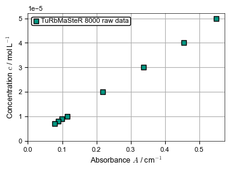

```python
import matplotlib.pyplot as plt
import mod.my_plotter as pt

# Initialize plot
pt.init_plot(scl_a4=1, page_lnewdth_cm=10)

# Display the imported data with matplotlib
fig, ax = plt.subplots()

# Plot Data
ax.scatter(x=A, y=c, edgecolors='black', marker='s', color=pt.green, linewidths=1,
           zorder=1, label='TuRbMaSteR 8000 raw data')

ax.set_ylabel('Concentration $c$ / mol$\,$L$^{-1}$')
ax.set_xlabel('Absorbance $A$ / cm$^{-1}$')
ax.legend(loc='upper left', fontsize='small', framealpha=1, ncol=1)
ax.set_xlim([0, ax.get_xlim()[1]])
ax.set_ylim([0, ax.get_ylim()[1]])
ax.grid(True)
plt.tight_layout()
```

### 5.3.2 Estimating the Dependence With a Linear Model

Well, that sure looks like a linear dependence! In other words, let's check if our data (`(A,c)` pairs) can be represented by a **straight line** model given by the following equation:

$$ c^{*} = slope \cdot A^{*} + offset $$

where $c^{*}$ are predictions of the caffeine concentration data based on given absorbance values $A^{*}$. Our so called **regression coefficients** are the $slope$ and the $offset$ of our straight line.

Our task of finding a functional relationship $c=f(A)$ now changed to the task of finding the **optimal** regression coefficients, i.e. *fitting* this model equation to the given data. Today, we'll do this very basic by simple trial and error. Obviously, there are better ways of finding these coefficients. Next week we will investigate how numerical optimization can be used!

There are various ways to quantify, how good our model represents the underlying data. For linear regression models you often see the coefficient of determination $R^2$ being used that is calculated by

$$R^{2} = 1 - \frac{SS_{res}}{SS_{tot}} = 1 - \frac{\sum_i (c_i-c^*_i)^2}{\sum_i (c_i-\bar{c})^2}$$

where, $SS_{tot}$ represents the sum of squared distances between your data points and their mean value. $SS_{res}$ represents the sum of the squared distances between your data points and the *straight line*, i.e. your *modeled* values . A value of $R^2=1$ means that your model ($c^*_i$) is identical to the given data points ($c_i$) and therefore represents a *perfect fit*.

In the code example below, you can estimate $slope$ and $offset$ by hand and calculate the model and it's coefficient of determination. Finally, everything is visualized. Can you find the optimal values of $slope$ and $offset$? Congratulations, you just *"trained"* your first data-driven model!

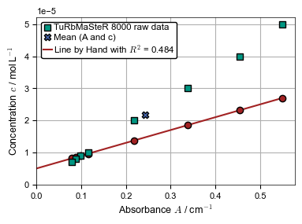

```python
# Put everything inside a function to make playing with the parameters easier (less scrolling)
def linear_fit_by_hand(slope_by_hand, offset_by_hand, c, A):
    # Calculate the mean of the c and A data
    c_mean = np.mean(c)
    A_mean = np.mean(A)

    # Calculate our "new" data points based on the linear model and the provided coefficients
    A_fit = np.linspace(0, max(A), 100)
    c_fit = slope_by_hand*A_fit + offset_by_hand
    c_fit_on_data = slope_by_hand*A + offset_by_hand

    # Calculate R² (coefficient of determination)
    SS_tot = np.sum((c-np.mean(c))**2)
    SS_res = np.sum((c-c_fit_on_data)**2)
    R2 = 1-(SS_res/SS_tot)

    # Plot everything
    fig, ax = plt.subplots()

    ax.scatter(x=A, y=c, edgecolors='black', marker='s', color=pt.green,
               linewidths=1, zorder=3, label='TuRbMaSteR 8000 raw data')
    ax.scatter(x=A_mean, y=c_mean, edgecolors='black', marker='X', color=pt.blue,
               zorder=2, label='Mean (A and c)')
    ax.plot(A_fit, c_fit, color=pt.red, zorder=1, label='Line by Hand with $R^{2}$'+f' = {np.round(R2,4)}')
    ax.scatter(x=A, y=c_fit_on_data, edgecolors='black', marker='o', color=pt.red,
               linewidths=1, zorder=2)
    ax.set_ylabel('Concentration $c$ / mol$\,$L$^{-1}$') # define the axis label
    ax.set_xlabel('Absorbance $A$ / cm$^{-1}$')
    ax.legend(loc='upper left', fontsize='small', framealpha=1, ncol=1)
    ax.set_xlim([0, ax.get_xlim()[1]])
    ax.set_ylim([0, ax.get_ylim()[1]])
    ax.grid(True)
    plt.tight_layout() # Adjust canvas so axes and data fits in the given space

# Define the variable: "slope_by_hand" and "offset_by_hand"
slope_by_hand = 4e-5
offset_by_hand = 5e-6

linear_fit_by_hand(slope_by_hand, offset_by_hand, c, A)
```

### 5.3.2 Save Processed Data as `.npy` Files

1. Data availability and transfer: Saving processed data makes it accessible for other python scripts at a later point in time.
2. Intermediate data storage: Processing tasks that take a very long time to execute (e.g. the import of extremely large .xlsx files) can be sped up when the numerical data is saved as a `.npy` file. Re-importing the `.npy` files is significantly faster!
3. Not having to do the *processing* every time: You only need to perform certain tasks once, but have to save your results.

- [`np.save(FILE, ARR)`](https://numpy.org/doc/stable/reference/generated/numpy.save.html#numpy.save): Save the numpy-array `ARR` in `FILE` (don't forget the `.npy` file format). `.npy` files are able to store a **single** (1) arbitrary numpy-array.
  - If you want to store multiple arrays in a single `.npy` file, you can *"condense"* them together in a `dict`.
  - `np.save( )` will take a `dict` directly but convert it into a numpy-array of objects. This will have implications for the re-import as it requires data transformations called *pickling*.
- [`np.load(FILE, allow_pickle=True)`](https://numpy.org/doc/stable/reference/generated/numpy.load.html): Load the numpy-array stored in `FILE`.
  - If you stored a `dict`, the result of `np.load( )` is a numpy-array (see above) of dimension 0. When you want to access the actual `dict`, you have to use the `.item( )` method.
  - Loading a `.npy` file with a stored `dict` requires some data transformations, called *pickling*. Doing this from untrusted sources is **strongly advised against**, as this may execute arbitrary (and harmful) code. The `allow_pickle=True` option requires you to actively allow the import of a file, as some sort of safety mechanism. For your own files, however, just make it a habit of always using this argument as `True`.

> ***Note:*** There are other ways and packages of saving and loading files (e.g. via `JSON` files). Just find a way that works for you and stick with it!

```python
# Save processed numerical data to the working directory
import numpy as np

# Set the path variable as a directory path string
path_to_archive = './export/'

# Save three .npy files with various arrays
np.save(path_to_archive + 'A_series_exp.npy', A)
np.save(path_to_archive + 'c_series_exp.npy', c)
np.save(path_to_archive + 'regression_coefficients.npy', {'slope': slope_by_hand, 'offset':offset_by_hand})

# Now we can re-import the saved data with np.load (this could be done in any other script)
A_reimport = np.load(path_to_archive + 'A_series_exp.npy')
c_reimport = np.load(path_to_archive + 'c_series_exp.npy')
print('The re-imported c values of type', type(c_reimport) ,'are', c_reimport)

# Try to remove .item() and see how it affects the datatype of rc_reimport!
rc_reimport = np.load(path_to_archive + 'regression_coefficients.npy', allow_pickle=True).item()
print('The re-imported regression coefficients of type', type(rc_reimport), 'are', rc_reimport)
```

```
The re-imported c values of type <class 'numpy.ndarray'> are [5.e-05 4.e-05 3.e-05 2.e-05 1.e-05 9.e-06 8.e-06 7.e-06]
The re-imported regression coefficients of type <class 'dict'> are {'slope': 4e-05, 'offset': 5e-06}
```